# Midterm

Sylvia Baeyens,

due 10/22/2021

# Introduction

This midterm project will look at the relationship between meat consumption and anemia prevalance in low and middle income countries.

Anemia is one of the most common medical conditions among menopausal women. Anemia is defined as a condition where the body lacks enough red blood cells to carry sufficient oxygen. Anemia is associated with many health risk factors and increased fatigue.

The main cause of anemia is iron deficiency. Iron is required to produce hemoglobin, a protein in red blood cells which binds to oxygen. Another secondary cause of anemia is blood loss, which occurs cyclically, usually monthly, in menopausal women; therefore, menopausal women are at an increased risk for anemia.

Iron can be consumed through diet in two forms: heme and non-heme iron. Heme iron is found only in animal products, such as red meat and poultry. Non-heme iron is plant based, and can be found in food sources such as nuts, legumes, and leafy greens. Heme iron is more readibly absorbed by the body than non-heme iron; non-heme iron often requires secondary vitamins, such as vitamin C, to upregulate proper absorption. While it is certainly possible to avoid an iron deficiency on a plant-based diet, most plant-based individuals choose to supplement their diet with iron supplements.

This midterm will focus solely on lower and middle income countries, as information on proper diet and supplementation is not readily available to these populations and the economic burden of anemia is greater.

# Methods

In order to answer the main question, multiple data sets were acquired from various sources. The data can be organized into 3 categories: anemia data, meat consumption data, and country data.

## Anemia Data

The data sets related to the prevalence of anemia in 15-49 year old women in low and middle income countries (LMIC) were exported from ghdx.healthdata.org. This data was collected by the Institute of Health Metrics and Evaluation with the funding from the Bill and Melinda Gates Foundation between January 2000 and December 2019. It was published in 2021. There were three different csv files in this set, one for mild anemia, one for moderate anemia, and one for severe anemia. The thresholds for these distinctions can be found in the paper *“Anemia prevalence in women of reproductive age in low- and middle-income countries between 2000 and 2018”*, published in **Nature Medicine** in 2021, and they vary between pregnant and non-pregnant women. The data sets detailed the prevalence of each kind of anemia every year in 82 LMICs at a 5x5km level. These csv’s were downloaded from the site manually and read into data tables in the R code. From there, variable names were changed to improve ease of merging. Instead of keeping the data at the 5x5km level, the mean anemia prevalence was found by country and year. Finally, the three data tables (moderate, mild, and severe) were merged into the data table “TotalAnemia”. This table included all 82 countries and the mild, moderate, and severe percentages of anemia prevalence for every year from 2000 to 2019. No values were found to be missing or unreasonable.

## Meat Consumption Data

The data set related to meat food supply quantity in terms of kilograms per capita per year was exported from ourworldindata.org. This data was sourced from data published by the United Nations Food and Agricultural Organization (FAO) in 2020. The data was collected from 1961 to 2017. This csv file was also exported manually from the website and read into a data table within the R code. It contains data from 215 countries and was not found to have any missing values. The data only had 4 variables: the country name, 3 letter country code, year, and meat food supply quantity; these variables were renamed for ease of use and to match the names of the anemia data table.

## Country Data & Final Data Table

Following preliminary data cleanup and wrangling, the TotalAnemia and meatData data tables were merged together by country and year to create a new data table: TotalData. All observations from the TotalAnemia data table were kept. To add a final level of analysis, a country code data set was downloaded and read in by the R code. This csv file was found on datahub.io, and lists every country, along with its three letter country code, continent, and other identifying information; only the three letter code and continent were selected for. This country code data set was then merged with the TotalData set by code, so that every observation now included the continent as well.

# Preliminary Results

**Quantiles (minimum, 25%, median, 75%, maximum) for Selected Variables in TotalData data frame**

| consumption | mild_anemia_percentage | moderate_anemia_percentage | severe_anemia_percentage |
| --- | --- | --- | --- |
| 2.790 | 0.0622677 | 0.0243576 | 0.0008969 |
| 12.300 | 0.1261958 | 0.1084639 | 0.0062583 |
| 18.765 | 0.1729187 | 0.1514557 | 0.0112407 |
| 34.860 | 0.1901257 | 0.2072797 | 0.0167453 |
| 100.680 | 0.2536185 | 0.3556498 | 0.0535393 |

The values for mild and anemia prevalence appear very similar, while the prevalence of severe anemia is much lower. For all further visualization and analysis, these three percentages will be summed to find the total percentage of women in each country between the ages of 15 and 49 with anemia.

The first step in visualizing data was viewing trends in total anemia prevalence for every country. To do this, the prevalence of mild, moderate, and severe anemia were summed together for every year and country. This data is visualized below, separated into the various continents represented for ease of viewing. A trend line was applied to each plot. This visualization was done to see if there are any trends over time of anemia prevalence.

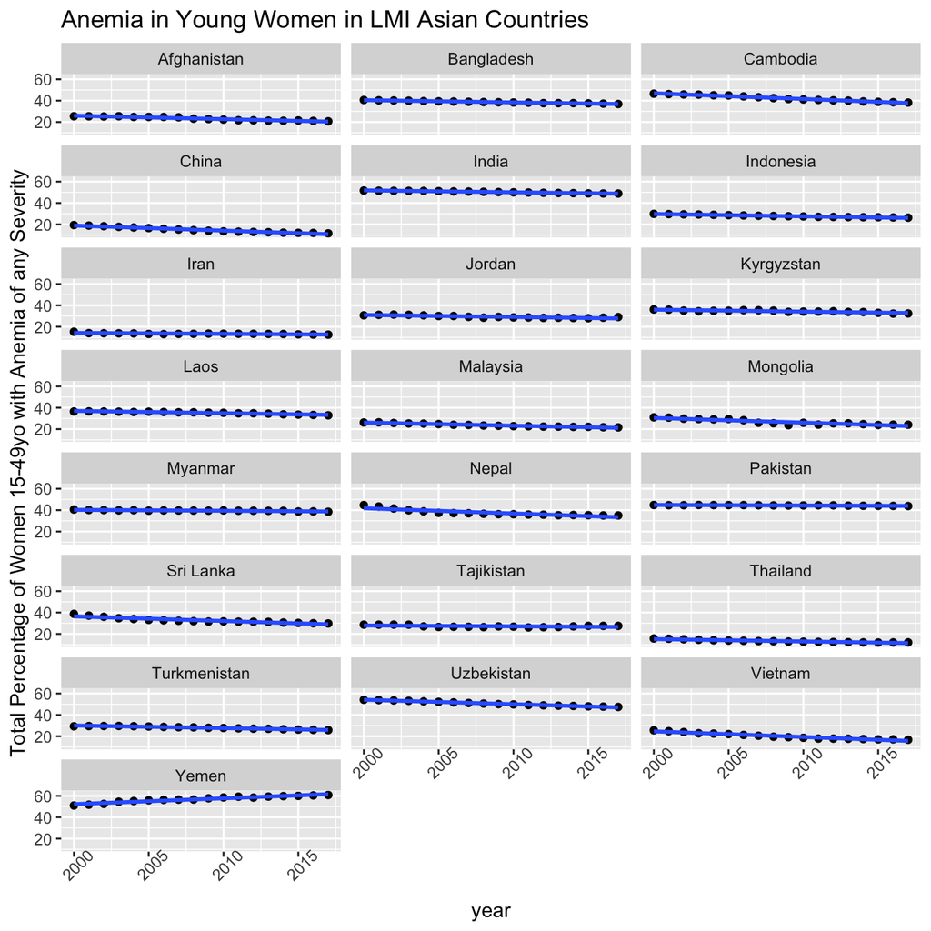

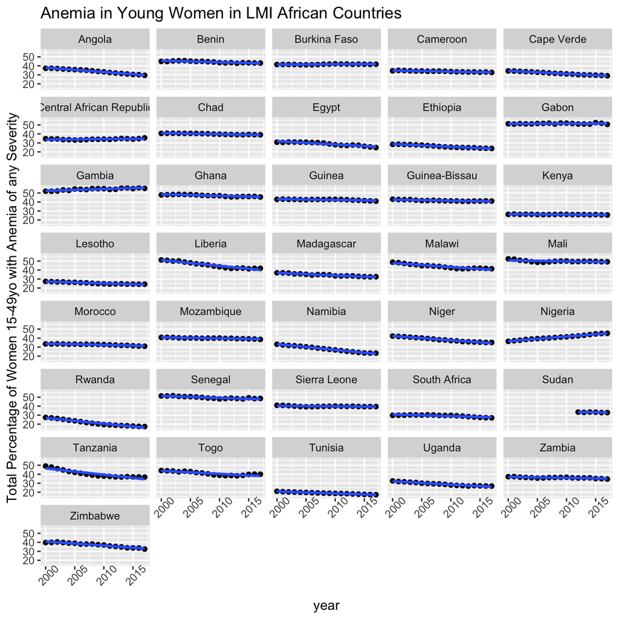

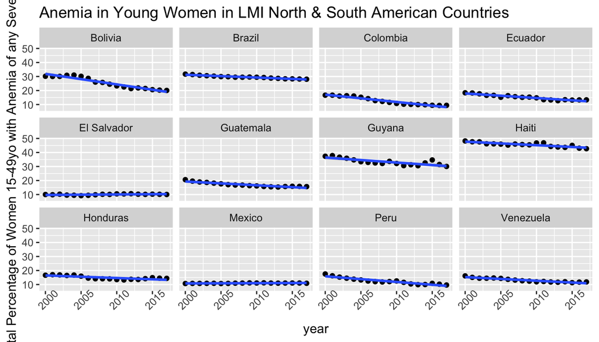

From these 3 graphs, it does appear that during the time period between 2000 and 2017, the prevalence of anemia decreased very slightly in the majority of these LMICs, as shown by the slight negative slope of the best fit trend line. The total percentage of women between the ages of 15-49 with anemia ranges from 10-60%, depending on the country.

Next, the average meat consumption in terms of kilograms per capita and the average anemia prevalence between the years of 2000 and 2017 was found for each country. This was done to compare meat consumption and anemia prevalence between these various countries.

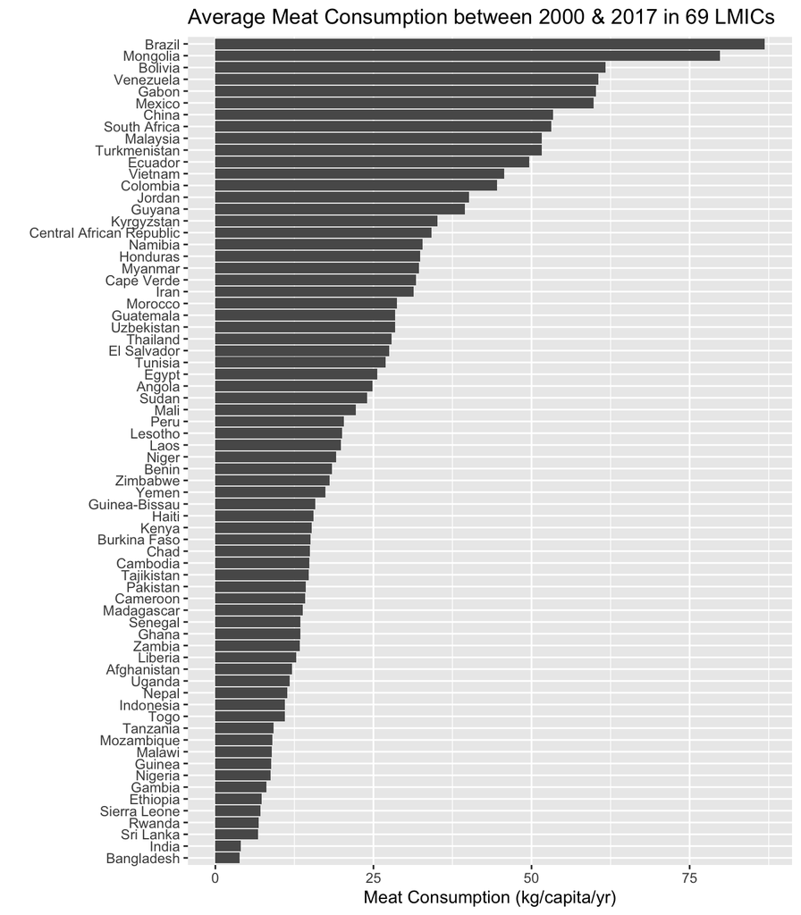

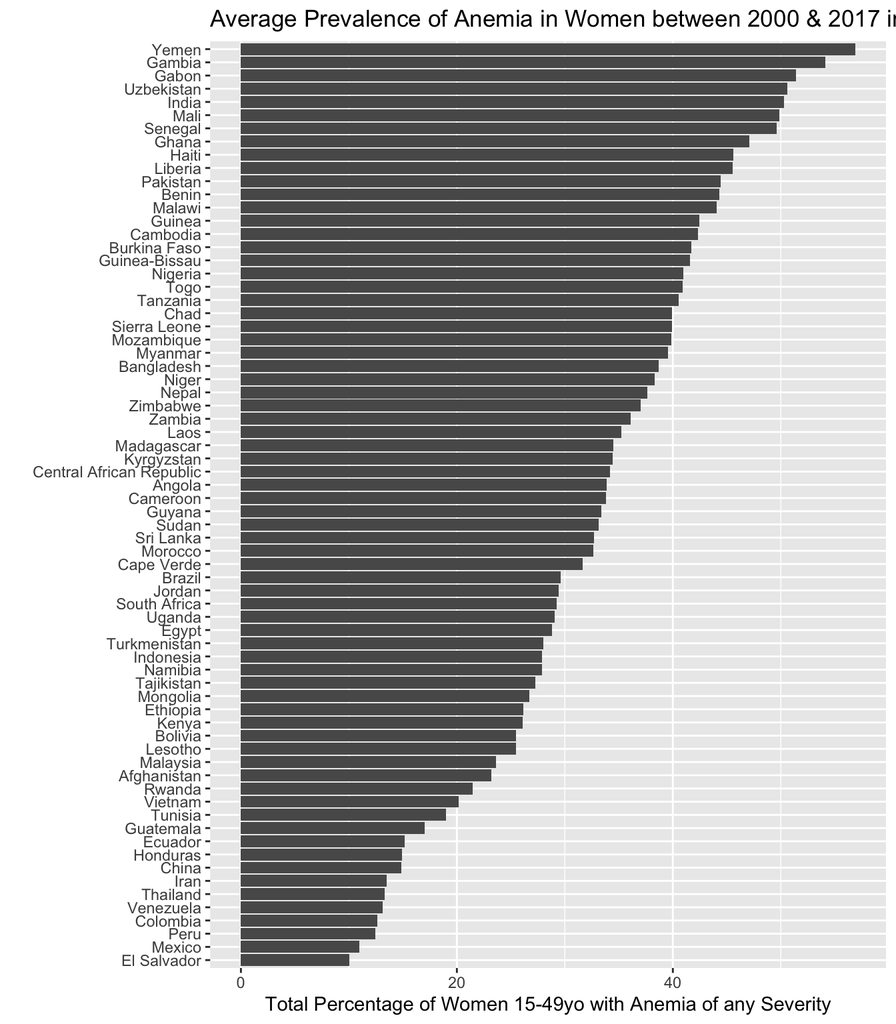

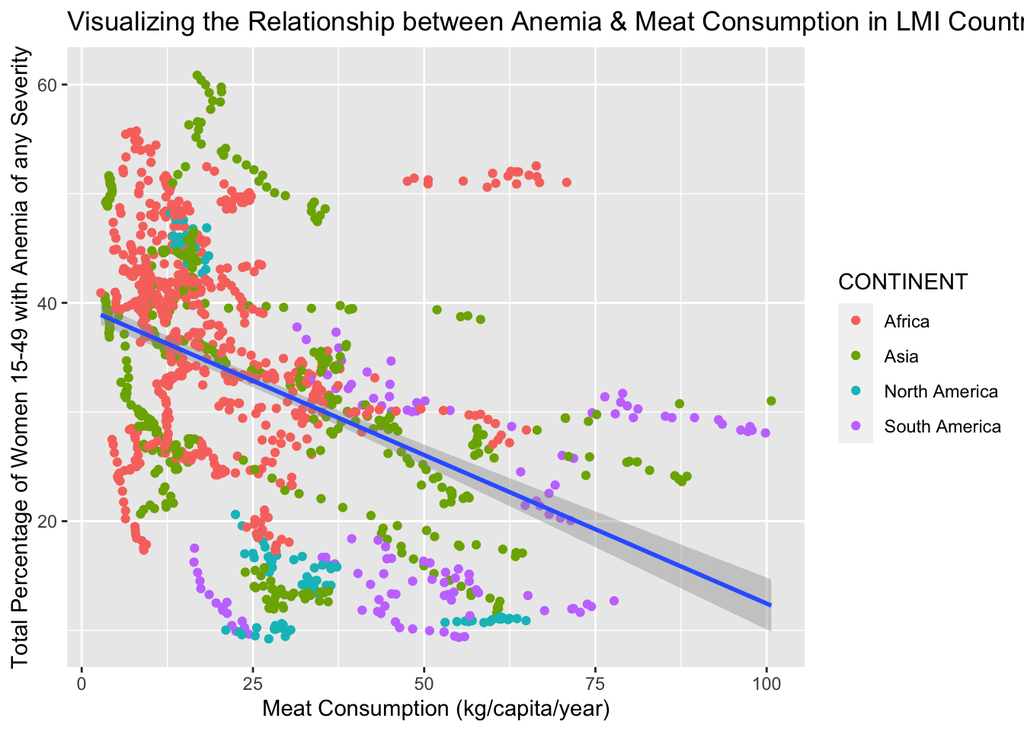

The final level of analysis included computing the correlation coefficients between the prevalance of various severieties of anemia and meat consumption. These coefficients are shown in the table below.

**Correlation Coefficients between Prevalance of various Severities of Anemia & Meat Consumption**

| Mild Anemia | Moderate Anemia | Severe Anemia |
| --- | --- | --- |
| -0.4129967 | -0.4320308 | -0.3515256 |

The values in the above table confirm the negative relationship between meat consumption and anemia prevalence, apparent in all 3 types of anemia. As the magnitude of these 3 coefficients fall between0.3 and 0.5, they indicate a low correlation.

# Conclusion

Based on the data presented above, there is a low negative correlation between meat consumption and anemia prevalance. There are likely many other factors affecting the high levels of anemia found in these LMICs, some of which are also related to diet. Further research could look at other factors, such as the consumption of other minerals and vitamins or the prevalence of other blood and digestive-related diseases.

It is positive to see that the prevalance of anemia is slowly decreasing, and it would be interesting to look into why this is occuring as well.

Comparing these results to those of more prosperous countries could be a final direction for this research to go into.